# Assignment 3: Microsimulation

Published

January 30, 2023

```r
#Use install.packages("XXXX") if you don't have any of these installed
library(readxl)
library(flextable)
library(ggplot2)
library(dplyr)
library(scales)
library(data.table)
theme_set(theme_bw()) #Makes ggplots look better
```

# 1. Vectorization and profiling

In this section, we are going to take two versions of the microsimlation model from the 2018 tutorial by Krijkamp et. al. and compare their runtime. This will help us see the benefits of vectorization for microsimulation models and provide practice with profiling code. Profiling helps us identify which parts of our code are slowest so we can improve them. Code can always be more efficient, but our time is limited. The goal should be “fast enough”, not “fully optimized”.

First, install [the profvis r package](http://rstudio.github.io/profvis/index.html) from CRAN by running:

```
install.packages("profvis")
```

In the next three chunks, I’ve provided the code from the microsimulation tutorial. In the fourth chunk, I’ve provided code to profile this code using the profvis package. You don’t need to change anything in any of these code chunks. Just run all 4 in order and then answer the questions at the bottom using the Profile1 and Profile2 graphical user interfaces that are created after running the fourth code chunk.

This code is meant to be run by you in Rstudio but doesn’t need to be re-run each time you render the document to HTML, which is why the “eval: false” option is at the top of each code chunk.

## Parameters

```r
# Model input
n.i   <- 100000                # number of simulated individuals
n.t   <- 30                    # time horizon, 30 cycles
v.n   <- c("H","S1","S2","D")  # the model states: Healthy (H), Sick (S1), Sicker (S2), Dead (D)
n.s   <- length(v.n)           # the number of health states
v.M_1 <- rep("H", n.i)         # everyone begins in the healthy state
d.c   <- d.e <- 0.03           # equal discounting of costs and QALYs by 3%
v.Trt <- c("No Treatment", "Treatment") # store the strategy names

# Transition probabilities (per cycle)
p.HD    <- 0.005               # probability to die when healthy
p.HS1   <- 0.15                  # probability to become sick when healthy
p.S1H   <- 0.5                   # probability to become healthy when sick
p.S1S2  <- 0.105                 # probability to become sicker when sick
rr.S1   <- 3                     # rate ratio of death when sick vs healthy
rr.S2   <- 10                    # rate ratio of death when sicker vs healthy
r.HD    <- -log(1 - p.HD)      # rate of death when healthy
r.S1D   <- rr.S1 * r.HD          # rate of death when sick
r.S2D   <- rr.S2 * r.HD          # rate of death when sicker
p.S1D   <- 1 - exp(- r.S1D)    # probability to die when sick
p.S2D   <- 1 - exp(- r.S2D)    # probability to die when sicker

# Cost and utility inputs
c.H     <- 2000                # cost of remaining one cycle healthy
c.S1    <- 4000                # cost of remaining one cycle sick
c.S2    <- 15000               # cost of remaining one cycle sicker
c.Trt   <- 12000               # cost of treatment (per cycle)

u.H     <- 1                   # utility when healthy
u.S1    <- 0.75                # utility when sick
u.S2    <- 0.5                 # utility when sicker
u.Trt   <- 0.95                # utility when sick(er) and being treated
```

## Unvectorized model functions

```r
# The MicroSim function for the simple microsimulation of the 'Sick-Sicker' model keeps track of what happens to each individual during each cycle.

MicroSim <- function(v.M_1, n.i, n.t, v.n, d.c, d.e, TR.out = TRUE, TS.out = TRUE, Trt = FALSE, seed = 1) {
# Arguments:
  # v.M_1:   vector of initial states for individuals
  # n.i:     number of individuals
  # n.t:     total number of cycles to run the model
  # v.n:     vector of health state names
  # d.c:     discount rate for costs
  # d.e:     discount rate for health outcome (QALYs)
  # TR.out:  should the output include a microsimulation trace? (default is TRUE)
  # TS.out:  should the output include a matrix of transitions between states? (default is TRUE)
  # Trt:     are the n.i individuals receiving treatment? (scalar with a Boolean value, default is FALSE)
  # seed:    starting seed number for random number generator (default is 1)
# Makes use of:
  # Probs:   function for the estimation of transition probabilities
  # Costs:   function for the estimation of cost state values
  # Effs:    function for the estimation of state specific health outcomes (QALYs)

  v.dwc <- 1 / (1 + d.c) ^ (0:n.t)   # calculate the cost discount weight based on the discount rate d.c
  v.dwe <- 1 / (1 + d.e) ^ (0:n.t)   # calculate the QALY discount weight based on the discount rate d.e

 # create the matrix capturing the state name/costs/health outcomes for all individuals at each time point
  m.M <- m.C <- m.E <-  matrix(nrow = n.i, ncol = n.t + 1,
                               dimnames = list(paste("ind", 1:n.i, sep = " "),
                                               paste("cycle", 0:n.t, sep = " ")))

  m.M[, 1] <- v.M_1                     # indicate the initial health state

  for (i in 1:n.i) {
    set.seed(seed + i)                  # set the seed for every individual for the random number generator
    m.C[i, 1] <- Costs(m.M[i, 1], Trt)  # estimate costs per individual for the initial health state conditional on treatment
    m.E[i, 1] <- Effs (m.M[i, 1], Trt)  # estimate QALYs per individual for the initial health state conditional on treatment

    for (t in 1:n.t) {
      v.p <- Probs(m.M[i, t])           # calculate the transition probabilities at cycle t

      m.M[i, t + 1] <- sample(v.n, prob = v.p, size = 1)  # sample the next health state and store that state in matrix m.M
      m.C[i, t + 1] <- Costs(m.M[i, t + 1], Trt)   # estimate costs per individual during cycle t + 1 conditional on treatment
      m.E[i, t + 1] <- Effs( m.M[i, t + 1], Trt)   # estimate QALYs per individual during cycle t + 1 conditional on treatment

    } # close the loop for the time points
    if(i/100 == round(i/100,0)) {          # display the progress of the simulation
      cat('\r', paste(i/n.i * 100, "% done", sep = " "))
    }
  } # close the loop for the individuals

  tc <- m.C %*% v.dwc       # total (discounted) cost per individual
  te <- m.E %*% v.dwe       # total (discounted) QALYs per individual

  tc_hat <- mean(tc)        # average (discounted) cost
  te_hat <- mean(te)        # average (discounted) QALYs

  if (TS.out == TRUE) {  # create a  matrix of transitions across states
    TS <- paste(m.M, cbind(m.M[, -1], NA), sep = "->") # transitions from one state to the other
    TS <- matrix(TS, nrow = n.i)
    rownames(TS) <- paste("Ind",   1:n.i, sep = " ")   # name the rows
    colnames(TS) <- paste("Cycle", 0:n.t, sep = " ")   # name the columns
  } else {
    TS <- NULL
  }

  if (TR.out == TRUE) { # create a trace from the individual trajectories
    TR <- t(apply(m.M, 2, function(x) table(factor(x, levels = v.n, ordered = TRUE))))
    TR <- TR / n.i                                       # create a distribution trace
    rownames(TR) <- paste("Cycle", 0:n.t, sep = " ")     # name the rows
    colnames(TR) <- v.n                                  # name the columns
  } else {
    TR <- NULL
  }

  results <- list(m.M = m.M, m.C = m.C, m.E = m.E, tc = tc, te = te, tc_hat = tc_hat, te_hat = te_hat, TS = TS, TR = TR) # store the results from the simulation in a list
  return(results)  # return the results
}  # end of the MicroSim function


#### Probability function
# The Probs function that updates the transition probabilities of every cycle is shown below.

Probs <- function(M_it) {
  # M_it:    health state occupied by individual i at cycle t (character variable)

  v.p.it <- rep(NA, n.s)     # create vector of state transition probabilities
  names(v.p.it) <- v.n       # name the vector

  # update v.p.it with the appropriate probabilities
  v.p.it[M_it == "H"]  <- c(1 - p.HS1 - p.HD, p.HS1, 0, p.HD)                  # transition probabilities when healthy
  v.p.it[M_it == "S1"] <- c(p.S1H, 1- p.S1H - p.S1S2 - p.S1D, p.S1S2, p.S1D)   # transition probabilities when sick
  v.p.it[M_it == "S2"] <- c(0, 0, 1 - p.S2D, p.S2D)                            # transition probabilities when sicker
  v.p.it[M_it == "D"]  <- c(0, 0, 0, 1)                                        # transition probabilities when dead
  ifelse(sum(v.p.it) == 1, return(v.p.it), print("Probabilities do not sum to 1")) # return the transition probabilities or produce an error
}


### Costs function
# The Costs function estimates the costs at every cycle.

Costs <- function (M_it, Trt = FALSE) {
  # M_it: health state occupied by individual i at cycle t (character variable)
  # Trt:  is the individual being treated? (default is FALSE)

  c.it <- 0                                  # by default the cost for everyone is zero
  c.it[M_it == "H"]  <- c.H                  # update the cost if healthy
  c.it[M_it == "S1"] <- c.S1 + c.Trt * Trt   # update the cost if sick conditional on treatment
  c.it[M_it == "S2"] <- c.S2 + c.Trt * Trt   # update the cost if sicker conditional on treatment
  return(c.it)                                 # return the costs
}


### Health outcome function
# The Effs function to update the utilities at every cycle.

Effs <- function (M_it, Trt = FALSE, cl = 1) {
  # M_it: health state occupied by individual i at cycle t (character variable)
  # Trt:  is the individual treated? (default is FALSE)
  # cl:   cycle length (default is 1)

  u.it <- 0                      # by default the utility for everyone is zero
  u.it[M_it == "H"]  <- u.H      # update the utility if healthy
  u.it[M_it == "S1"] <- Trt * u.Trt + (1 - Trt) * u.S1  # update the utility if sick conditional on treatment
  u.it[M_it == "S2"] <- u.S2     # update the utility if sicker
  QALYs <-  u.it * cl            # calculate the QALYs during cycle t
  return(QALYs)                  # return the QALYs
}
```

## Vectorized model functions

```r
# THE NEW samplev() FUNCTION
# efficient implementation of the rMultinom() function of the Hmisc package ####

samplev <- function (probs, m) {
  d <- dim(probs)
  n <- d[1]
  k <- d[2]
  lev <- dimnames(probs)[[2]]
  if (!length(lev))
    lev <- 1:k
  ran <- matrix(lev[1], ncol = m, nrow = n)
  U <- t(probs)
  for(i in 2:k) {
    U[i, ] <- U[i, ] + U[i - 1, ]
  }
  if (any((U[k, ] - 1) > 1e-05))
    stop("error in multinom: probabilities do not sum to 1")

  for (j in 1:m) {
    un <- rep(runif(n), rep(k, n))
    ran[, j] <- lev[1 + colSums(un > U)]
  }
  ran
}
# The MicroSim function for the simple microsimulation of the 'Sick-Sicker' model keeps track of what happens to each individual during each cycle.

MicroSim_vectorized <- function(v.M_1, n.i, n.t, v.n, d.c, d.e, TR.out = TRUE, TS.out = TRUE,
                     Trt = FALSE, seed = 1) {
# Arguments:
  # v.M_1:   vector of initial states for individuals
  # n.i:     number of individuals
  # n.t:     total number of cycles to run the model
  # v.n:     vector of health state names
  # d.c:     discount rate for costs
  # d.e:     discount rate for health outcome (QALYs)
  # TR.out:  should the output include a Microsimulation trace? (default is TRUE)
  # TS.out:  should the output include a matrix of transitions between states? (default is TRUE)
  # Trt:     are the n.i individuals receiving treatment? (scalar with a Boolean value, default is FALSE)
  # seed:    starting seed number for random number generator (default is 1)
# Makes use of:
  # Probs:   function for the estimation of transition probabilities
  # Costs:   function for the estimation of cost state values
  # Effs:    function for the estimation of state specific health outcomes (QALYs)

  v.dwc <- 1 / (1 + d.c) ^ (0:n.t)   # calculate the cost discount weight based on the discount rate d.c
  v.dwe <- 1 / (1 + d.e) ^ (0:n.t)   # calculate the QALY discount weight based on the discount rate d.e

 # Create the matrix capturing the state name/costs/health outcomes for all individuals at each time point
  m.M <- m.C <- m.E <-  matrix(nrow = n.i, ncol = n.t + 1,
                               dimnames = list(paste("ind", 1:n.i, sep = " "),
                                               paste("cycle", 0:n.t, sep = " ")))

  m.M[, 1] <- v.M_1                     # indicate the initial health state

    set.seed(seed)                  # set the seed for every individual for the random number generator
    m.C[, 1] <- Costs_vectorized(m.M[, 1], Trt)  # estimate costs per individual for the initial health state
    m.E[, 1] <- Effs_vectorized(m.M[, 1], Trt)  # estimate QALYs per individual for the initial health state

    for (t in 1:n.t) {
      m.p <- Probs_vectorized(m.M[, t])           # calculate the transition probabilities at cycle t

      m.M[, t + 1] <- samplev( prob = m.p, m = 1)  # sample the next health state and store that state in matrix m.M
      m.C[, t + 1] <- Costs_vectorized(m.M[, t + 1], Trt)   # estimate costs per individual during cycle t + 1 conditional on treatment
      m.E[, t + 1] <- Effs_vectorized( m.M[, t + 1], Trt)   # estimate QALYs per individual during cycle t + 1 conditional on treatment
        cat('\r', paste(round(t/n.t * 100), "% done", sep = " "))       # display the progress of the simulation

    } # close the loop for the time points


  tc <- m.C %*% v.dwc       # total (discounted) cost per individual
  te <- m.E %*% v.dwe       # total (discounted) QALYs per individual

  tc_hat <- mean(tc)        # average (discounted) cost
  te_hat <- mean(te)        # average (discounted) QALYs

  if (TS.out == TRUE) {  # create a matrix of transitions across states
    TS <- paste(m.M, cbind(m.M[, -1], NA), sep = "->") # transitions from one state to the other
    TS <- matrix(TS, nrow = n.i)
    rownames(TS) <- paste("Ind",   1:n.i, sep = " ")   # name the rows
    colnames(TS) <- paste("Cycle", 0:n.t, sep = " ")   # name the columns
  } else {
    TS <- NULL
  }

  if (TR.out == TRUE) {
    TR <- t(apply(m.M, 2, function(x) table(factor(x, levels = v.n, ordered = TRUE))))
    TR <- TR / n.i                                       # create a distribution trace
    rownames(TR) <- paste("Cycle", 0:n.t, sep = " ")     # name the rows
    colnames(TR) <- v.n                                  # name the columns
  } else {
    TR <- NULL
  }
  results <- list(m.M = m.M, m.C = m.C, m.E = m.E, tc = tc, te = te, tc_hat = tc_hat, te_hat = te_hat, TS = TS, TR = TR) # store the results from the simulation in a list
  return(results)  # return the results
}  # end of the MicroSim function


#### Probability function
# The Probs function that updates the transition probabilities of every cycle is shown below.

Probs_vectorized <- function(M_it) {
  # M_it:    health state occupied by individual i at cycle t (character variable)

  m.p.it <- matrix(NA, n.s, n.i)     # create vector of state transition probabilities
  rownames(m.p.it) <- v.n            # assign names to the vector

  # update the v.p with the appropriate probabilities
  m.p.it[,M_it == "H"]  <- c(1 - p.HS1 - p.HD, p.HS1, 0, p.HD)                  # transition probabilities when healthy
  m.p.it[,M_it == "S1"] <- c(p.S1H, 1- p.S1H - p.S1S2 - p.S1D, p.S1S2, p.S1D)   # transition probabilities when sick
  m.p.it[,M_it == "S2"] <- c(0, 0, 1 - p.S2D, p.S2D)                            # transition probabilities when sicker
  m.p.it[,M_it == "D"]  <- c(0, 0, 0, 1)                                        # transition probabilities when dead
  ifelse(colSums(m.p.it) == 1, return(t(m.p.it)), print("Probabilities do not sum to 1")) # return the transition probabilities or produce an error
}


### Costs function
# The Costs function estimates the costs at every cycle.

Costs_vectorized <- function (M_it, Trt = FALSE) {
  # M_it: health state occupied by individual i at cycle t (character variable)
  # Trt:  is the individual being treated? (default is FALSE)

  c.it <- 0                                  # by default the cost for everyone is zero
  c.it[M_it == "H"]  <- c.H                  # update the cost if healthy
  c.it[M_it == "S1"] <- c.S1 + c.Trt * Trt   # update the cost if sick conditional on treatment
  c.it[M_it == "S2"] <- c.S2 + c.Trt * Trt   # update the cost if sicker conditional on treatment
  c.it[M_it == "D"]  <- 0                    # update the cost if dead

  return(c.it)                                 # return the costs
}


### Health outcome function
# The Effs function to update the utilities at every cycle.

Effs_vectorized <- function (M_it, Trt = FALSE, cl = 1) {
  # M_it: health state occupied by individual i at cycle t (character variable)
  # Trt:  is the individual treated? (default is FALSE)
  # cl:   cycle length (default is 1)

  u.it <- 0                      # by default the utility for everyone is zero
  u.it[M_it == "H"]  <- u.H      # update the utility if healthy
  u.it[M_it == "S1"] <- Trt * u.Trt + (1 - Trt) * u.S1  # update the utility if sick conditional on treatment
  u.it[M_it == "S2"] <- u.S2     # update the utility if sicker
  u.it[M_it == "D"]  <- 0        # update the utility if dead

  QALYs <-  u.it * cl            # calculate the QALYs during cycle t
  return(QALYs)                  # return the QALYs
}
```

## Profiling

When looking at the .qmd file, you’ll see `#| eval: false` at the top of the chunk. this tells R not to run this chunk whenever you render your document. You should run this code chunk in Rstudio, after running the prior chunks in this section, in order to profile the code with the profvis package. This will create two different “Profile” tabs in RStudio which you will analyze to answer the questions below.

```r
library(profvis)
# Profile the vectorized version
profvis({
  sim_no_trt_vectorized  <- MicroSim_vectorized(v.M_1, n.i, n.t, v.n, d.c, d.e, Trt = FALSE) # run for no treatment
sim_trt_vectorized     <- MicroSim_vectorized(v.M_1, n.i, n.t, v.n, d.c, d.e, Trt = TRUE)  # run for treatment
})
# Profile the unvectorized version
profvis({
sim_no_trt  <- MicroSim(v.M_1, n.i, n.t, v.n, d.c, d.e, Trt = FALSE) # run for no treatment
sim_trt     <- MicroSim(v.M_1, n.i, n.t, v.n, d.c, d.e, Trt = TRUE)  # run for treatment
})
```

To answer these questions, look at the “Data” tabs of the Profile1 and Profile2 widgets that will appear when you run the above code in Rstudio.

What was the total time in miliseconds to run the vectorized and unvectorized versions of the simulation function? How many times slower is the unvectorized version compared to the vectorized version?

Within the microsim() function, what sub-function was being run for the greatest amount of time (non-vectorized version)?

Within the microsim_vectorized() function, what sub-function was being run for the greatest amount of time (vectorized version)?

# 2. Simulated decision tree

In this section, you will implement a version of the simulated decision tree from my papers about transfusion-transmitted Zika virus, discussed in class (see [Russell et. al. 2019](https://doi.org/10.7326/M18-2238), [Russell et. al. 2021](https://www.doi.org/10.1007/s10729-021-09557-1), and [Russell 2022](https://doi.org/10.7326/M20-6879)). Your model will use two variation reduction techniques: conditional Monte Carlo and simulating outcomes on the same cohort across each scenario, to improve the efficiency of the analysis. Lets get started!

We will assess a hypothetical pathogen inactivation technlogy that reduces the risk of transfusion-transmitted Zika by 95% and costs $18 per component transfused. As depicted below, my full simulation model consider adverse events to the transfusion recipient, their sexual partner, and an infant born to the transfusion recipient (if pregnant at the time of transfusion) or sexual partner (if pregnant at the time of sexual transmission). However, we’re going to only include adverse outcomes experienced by the tranfusion recipients and infants they have if they are pregnant at the time of transfusion. We will also simplify by ignoring cost and QALY discounting and productivity loss due to illness or death. I’ve also inflated the probability of Guillain-Barre Syndrome so that we can get a stable solution while simulating a smaller number of transfusion recipeints.

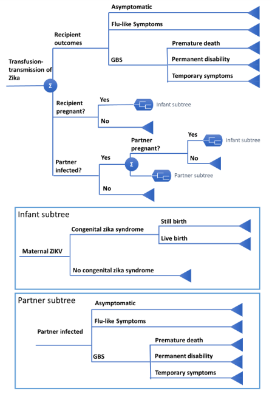

Model parameters are provided in an Excel file. This chunk reads in and displays the parameters. Note that some parameters are age specific. For a given transfusion recipient, we want to use the row with the largest value in `age_lower` that is below the transfusion recipient’s age. Parameters that do not vary by recipient age are entered only once and have 0 as the age_lower.

```r
t_params <- read_excel("params_assign3.xlsx", sheet="params")
t_params |>
  flextable() |>
  merge_v(j=c(1, 2, 3)) |> #Merge cells in first column with same value (group probabilities, costs, etc.)
  set_formatter(Value = label_comma()) |>
  theme_box() |> #Apply a theme for aesthetics
  autofit() #automatically set column widths to reasonable values
```

| Category | param_name | rname | value | age_lower |
| --- | --- | --- | --- | --- |
| Probability | Percent of Zika transmission prevented by pathogen inactivation | p_pathInact_prevent_TTZ | 0.9500 | 0 |
|  | Transmissibility of Zika in RBC components | p_transmit_RBC | 0.5000 | 0 |
|  | Transmissibility of Zika in PLT components | p_transmit_PLT | 0.5000 | 0 |
|  | Transmissibility of Zika in FFP components | p_transmit_FFP | 0.9000 | 0 |
|  | Zika fever | p_flu_like_symptoms | 0.1836 | 0 |
|  | Guillain-Barré | p_GBS | 0.0100 | 0 |
|  | Death from Guillain-Barré | p_GBS_death | 0.0258 | 0 |
|  | Permanent disability from Guillain-Barré | p_GBS_perm | 0.0000 | 0 |
|  |  |  | 0.0484 | 15 |
|  |  |  | 0.1210 | 20 |
|  |  |  | 0.2200 | 35 |
|  |  |  | 0.4880 | 65 |
|  | Congenital Zika syndrome | p_CZS | 0.1000 | 0 |
|  | Stillbirth after congenital transmission | p_stillborn_CZS | 0.4000 | 0 |
|  | Recipient pregnant | p_recip_pregnant_by_age | 0.0000 | 0 |
|  |  |  | 0.0702 | 15 |
|  |  |  | 0.1719 | 20 |
|  |  |  | 0.1869 | 25 |
|  |  |  | 0.1623 | 30 |
|  |  |  | 0.0909 | 35 |
|  |  |  | 0.0231 | 40 |
|  |  |  | 0.0000 | 45 |
| Cost | Pathogen inactivation per component | costPathInact | 18.0000 | 0 |
|  | True positive test result | costTP | 91.8000 | 0 |
|  | False positive test result | costFP | 91.8000 | 0 |
|  | Zika fever in recipient (hospitalized) | costFluR | 1,357.8192 | 0 |
|  | Guillain-Barré non-permanent (all in year 1) | costGBS | 61,675.5600 | 0 |
|  | Permanent disability from Guillain-Barré (annual for remaining life years) | costGBS_perm | 38,579.5764 | 0 |
|  | Death from Guillain-Barré | costGBS_death | 72,475.5600 | 0 |
|  | Normal delivery | costDelivery | 25,386.3720 | 0 |
|  | Infant testing | costInfantZikaTest | 242.7840 | 0 |
|  | Mother testing | costMotherZikaTest | 505.0080 | 0 |
|  | Stillbirth | costStillBirth | 6,644.8080 | 0 |
|  | Delivery with congenital Zika syndrome | costCZS_birth | 26,131.7880 | 0 |
|  | Lifetime medical costs with congenital Zika syndrome | costCZS_lifetime | 4,358,764.0080 | 0 |
| Utility | Baseline | uBaseline | 0.9000 | 0 |
|  | Zika fever, female recipient | uFluFemale | 0.5700 | 0 |
|  |  |  | 0.5800 | 20 |
|  |  |  | 0.6300 | 35 |
|  |  |  | 0.6100 | 50 |
|  |  |  | 0.5900 | 65 |
|  | Zika fever, male recipient | uFluMale | 0.5000 | 0 |
|  |  |  | 0.5900 | 20 |
|  |  |  | 0.5800 | 35 |
|  |  |  | 0.5500 | 50 |
|  |  |  | 0.5400 | 65 |
|  | Guillain-Barré, year 1 | uGBS_yr1 | 0.4000 | 0 |
|  | Congenital Zika syndrome | uCZS | 0.0000 | 0 |
| Duration | Zika fever, recipient | durationFlu | 21.0000 | 0 |
|  | Congenital Zika syndrome | CZS_QALYloss | 79.8000 | 0 |

I’ve put the parameters into a named list `l_params` for you. Note that parameters that depend on age are in the list as a tibble instead of a single value

```r
# Put parameters into named list l_params
params_freq_table <- table(t_params$rname)
l_params <- list()
for (param in names(params_freq_table)){
  if(params_freq_table[param]== 1){
    l_params[param]<-t_params[t_params$rname==param,]$value
  } else {
    l_params[[param]]<-tibble(
      "age_lower" = t_params[t_params$rname==param,]$age_lower,
      "value" = t_params[t_params$rname==param,]$value
    )
  }
}
```

## Sample cohort and baseline characteristics

```r
# Read in dataset
t_transfusion_cohort <- NA

# Sample 4,000 recipients
t_sim_cohort <- NA

# Assign their age
# t_sim_cohort <- t_sim_cohort |>
#   mutate(age = NA)
```

We want to simulate the recipients’ baseline survival: the number of years they will live post-transfusion assuming no transfusion transmission of Zika. Since post-transfusion survival data based on age and component mix transfused were not available for the US, survival is estimated with what I call a “Frankenstein approach”. The estimate combines 1-, 2-, 3-, 4-, and 5-year post-transfusion survival estimates from a US insurance claims analysis published in 2003 by Kleinman et. al., which is broken out only by 3 age groups, with multipliers derived from post-transfusion survival data from the SCANDAT database based on age and the number of red blood cell (RBC), platelet (PLT) and plasma (FFP) components transfused. The Kleinman US-based post-transfusion survival data are in an Excel sheet we’ll load as `t_US_survival` and the multipliers from SCANDAT are in another Excel sheet we’ll load as `t_SCANDAT_mult`. We also include background other cause mortality based on a lifetable, which we’ll read in as `t_ocm`.

```r
#Read in other cause mortality table and display first few rows
t_ocm <- read_excel("params_assign3.xlsx", sheet="other_cause_mortality")
t_ocm |> head() |> flextable()
```

| age | annual_prob_death |
| --- | --- |
| 0 | 0.005831063 |
| 1 | 0.000370078 |
| 2 | 0.000248410 |
| 3 | 0.000183835 |
| 4 | 0.000158093 |
| 5 | 0.000141899 |

```r
#Read in SCANDAT mortality multiplier table and display first few rows
t_SCANDAT_mult <- read_excel("params_assign3.xlsx", sheet="SCANDAT_death_multipliers")
t_SCANDAT_mult |> head() |> flextable()
```

| age_lower | RBC_lower | PLT_lower | FFP_lower | multiplier |
| --- | --- | --- | --- | --- |
| 65 | 5 | 5 | 0 | -0.4324025 |
| 65 | 1 | 5 | 0 | -0.4301306 |
| 65 | 1 | 5 | 5 | -0.4216571 |
| 65 | 0 | 5 | 5 | -0.4214426 |
| 65 | 5 | 5 | 5 | -0.4198788 |
| 65 | 5 | 1 | 0 | -0.4170327 |

```r
#Read in US post-transfusion survival data and display first few rows
t_US_survival <- read_excel("params_assign3.xlsx", sheet="US_posttransfusion_surv")
t_US_survival |> head() |> flextable()
```

| age_lower | year_posttransfusion | value |
| --- | --- | --- |
| 0 | 0 | 0.895 |
| 0 | 1 | 0.877 |
| 0 | 2 | 0.862 |
| 0 | 3 | 0.862 |
| 0 | 4 | 0.848 |
| 45 | 0 | 0.729 |

Next we write a function that, for each recipient (row) in `t_sim_cohort,` first creates a vector of the probability of surviving to year `i`, then randomly samples a baseline survival duration (survival without transfusion-transmitted Zika) from this distribution. Complete this function using the information in the comments.

NOTE: this function could probably be made more efficient using vectorization.

```r
#Takes t_sim_cohort and uBaseline, calculates remaining life years and QALYs assuming no transfusion-transmitted Zika and adds these as additional columns to t_sim_cohort
get_survival <- function(t_sim_cohort, #needs columsn units_rbc, units_plt, units_ffp and age
                         uBaseline){

  for (row in 1:nrow(t_sim_cohort)){
    #Preallocate v_survProb, a vector with the recipient's cumulative
    #. survival probability (e.g., probability of surviving to post-
    #. transfusion year X). The vector length should be 100 minus their
    #. age at the time of transfusion
    age <- NA
    v_survProb <- NA

    #SURVIVING YEAR 0
    #. Since tidyverse was too slow and I had to use
    #. data.table, I'm providing all the year 0
    #. code for you.

    #from t_US_survival, get the probabiltiy of surviving to post-
    #. transfusion year 1 based on the age at transfusion
    p_surv_unadjusted <- t_US_survival[year_posttransfusion==0 &
                                         age_lower <= recip_age,][
                                           age_lower==max(age_lower), value]

    #use t_ocm to calculate the probability they DON'T die from another cause
    p_survive_OCM <- 1 - t_ocm[age== recip_age, annual_prob_death]


    # Extract SCANDAT survival multiplier based on recipient's age
    #. and units transfused
    survival_multiplier <- t_SCANDAT_mult[RBC_lower <= t_sim_cohort[row,]$units_rbc &
                                          RBC_lower <= t_sim_cohort[row,]$units_rbc &
                                          RBC_lower <= t_sim_cohort[row,]$units_rbc &
                                          age_lower <= recip_age,][
                                            age_lower == max(age_lower) &
                                            RBC_lower == max(RBC_lower) &
                                            PLT_lower == max(PLT_lower) &
                                            FFP_lower == max(FFP_lower),
                                            multiplier]


    #Calculate probability recipient survives to 1 year post-transfusion
    #No need to edit
    v_survProb[[1]]<- p_surv_unadjusted +
      survival_multiplier*(p_survive_OCM - p_surv_unadjusted)

    #Calculate cumulative probability of surviving post-transfusion years 2-5
    #Applying same adjustment to the US survival data
    for (i in 2:5){
      recip_age <- NA
      p_survive_OCM <- NA
      p_surv_unadjusted <- NA

      v_survProb[i] <- p_surv_unadjusted +
        survival_multiplier*(p_survive_OCM - p_surv_unadjusted)
    }
    #Beyond post-transfusion year 5, cumulative survival is based only
    #. on the annual probablity of other cause death
    for(i in 6:length(v_survProb)){
      p_survive_OCM <- NA
      v_survProb[i] <- v_survProb[i-1]*p_survive_OCM
    }

    #sample recipeint's survival (number of post-transfusion years) and add as a
    #. column to t_sim_cohort
    #. I provide the calculation for you;
    #. see if you can figure out why this works
    survival <- sum(1-cumSurv > runif(1))
    t_sim_cohort[row,]$survival <- survival
  }

  #Add a colument baseline_QALYs to t_sim_cort, based on the survival and uBaseline
  t_sim_cohort <- t_sim_cohort |>
    mutate(baseline_QALYs = NA) #your code here

  return(t_sim_cohort)
}
```

Test it out: add survival to your cohort

```r
# Uncomment and add the arguments

# t_sim_cohort <- get_survival(NA)

# Uncomment to take a look
# summary(t_sim_cohort$survival)
# summary(t_sim_cohort$baseline_QALYs)
```

We want to add two more columns: a variable `p_pregnant` containing the probability a recipient is pregnant based on their sex and age, and a binary variable called `isPregnant` where we simulate whether they are pregnant or not.

```r
getPregnant <- function(t_sim_cohort, l_params){

  #use l_params$p_recip_pregnant_by_age to get probability femail
  #.  recipients are pregnant by age, assigning a probability
  #.  of 0 to male recipients
  #.  I did this for you
  setDT(t_sim_cohort)
  t_preg_by_age <- data.table(l_params$p_recip_pregnant_by_age)
  setnames(t_preg_by_age,
           c("age_lower", "value"),
           c("age", "p_pregnant"))
  t_sim_cohort <- t_preg_by_age[t_sim_cohort, roll = Inf, on="age"]

  #overwrite with 0 if recipient is male
  t_sim_cohort[, p_pregnant:=ifelse(is_female==0,
                                    0,
                                    p_pregnant)]

  # Now we'll create a vector of ranom numbers the same length
  #. as our recipients and use this to determine which
  #. recipients are pregnant
  rand_pregnant <- NA
  t_sim_cohort <- t_sim_cohort |>
    mutate(isPregnant = NA)

  return(t_sim_cohort)
}
```

Now apply your function to add the pregnancy variables `t_sim_cohort` and take a look at them.

```r
# Uncomment and add the arguments

# t_sim_cohort <- getPregnant(NA)

# Uncomment to take a look
# summary(t_sim_cohort$p_pregnant)
# summary(t_sim_cohort$isPregnant)
```